# Chapter exercise3 from ISLR book

## Exercise 3.1

''' The null hypotheses to Intercept is that means Except the benefit from the TV, radio and newspaper , other benefit – other budget is larger than 0, which rejects the H_0 which is cost = budget in more than 99%.

The null hypotheses to TV is that the benefit of TV ads possibility not equal than the budget of TV ads. There exists more than 99% possibility that benefit of TV ads is not equal than cost of it.

The null hypotheses to Radio is that the benefit of radio ads possibility not equal than the budget of radio ads. There exists more than 99% possibility that benefit of radio ads is not equal than cost of it.

The null hypotheses to newspaper is that the benefit of newspaper ads possibility not equal than the budget of newspaper ads. There exists more than 99% possibility that benefit of newspaper ads is not equal than cost of it. '''

## Exercise 3.2

KNN regression averages the closest observations to estimate prediction

KNN classifier assigns classification group based on majority of closest observations.

## Exercise 3.5

$ \hat{y}_{i} = x_{i} \times \frac{\sum_{i'=1}^{n}\left ( x_{i'} y_{i'} \right )}{\sum_{j=1}^{n} x_{j}^{2}} \\ \hat{y}_{i} = \sum_{i'=1}^{n} \frac{\left ( x_{i'} y_{i'} \right ) \times x_{i}}{\sum_{j=1}^{n} x_{j}^{2}} \\ \hat{y}_{i} = \sum_{i'=1}^{n} \left ( \frac{ x_{i} x_{i'} } { \sum_{j=1}^{n} x_{j}^{2} } \times y_{i'} \right ) \\ a_{i'} = \frac{ x_{i} x_{i'} } { \sum_{j=1}^{n} x_{j}^{2} } \\ $

## Exercise 3.6

Using equation (3.4), when $x_{i}=\bar{x}$, then $\hat{\beta_{1}}=0$ and $\hat{\beta_{0}}=\bar{y}$ and the equation for $\hat{y_{i}}$ evaluates to equal $\bar{y}$

## Exercise 3.11

```python
# part (a)
import numpy as np

np.random.seed(11)

s = np.random.normal(0,1,100)
x = s
d = np.random.normal(0,1,100)

y = 2*x + d

import statsmodels.api as sm

model1 = sm.OLS(y,x).fit()

model1.summary()
```

OLS Regression Results

| Dep. Variable: | y | R-squared: | 0.790 |
| --- | --- | --- | --- |
| Model: | OLS | Adj. R-squared: | 0.787 |
| Method: | Least Squares | F-statistic: | 371.4 |
| Date: | Thu, 31 Jan 2019 | Prob (F-statistic): | 2.82e-35 |
| Time: | 14:16:24 | Log-Likelihood: | -136.94 |
| No. Observations: | 100 | AIC: | 275.9 |
| Df Residuals: | 99 | BIC: | 278.5 |
| Df Model: | 1 |  |  |
| Covariance Type: | nonrobust |  |  |

|  | coef | std err | t | P>\|t\| | [0.025 | 0.975] |
| --- | --- | --- | --- | --- | --- | --- |
| x1 | 1.9754 | 0.103 | 19.272 | 0.000 | 1.772 | 2.179 |

| Omnibus: | 0.555 | Durbin-Watson: | 1.775 |
| --- | --- | --- | --- |
| Prob(Omnibus): | 0.758 | Jarque-Bera (JB): | 0.687 |
| Skew: | 0.077 | Prob(JB): | 0.709 |
| Kurtosis: | 2.624 | Cond. No. | 1.00 |

Warnings:  
[1] Standard Errors assume that the covariance matrix of the errors is correctly specified.

```python
# part (b)

model2 = sm.OLS(x,y).fit()

model2.summary()
```

OLS Regression Results

| Dep. Variable: | y | R-squared: | 0.790 |
| --- | --- | --- | --- |
| Model: | OLS | Adj. R-squared: | 0.787 |
| Method: | Least Squares | F-statistic: | 371.4 |
| Date: | Thu, 31 Jan 2019 | Prob (F-statistic): | 2.82e-35 |
| Time: | 14:16:24 | Log-Likelihood: | -57.048 |
| No. Observations: | 100 | AIC: | 116.1 |
| Df Residuals: | 99 | BIC: | 118.7 |
| Df Model: | 1 |  |  |
| Covariance Type: | nonrobust |  |  |

|  | coef | std err | t | P>\|t\| | [0.025 | 0.975] |
| --- | --- | --- | --- | --- | --- | --- |
| x1 | 0.3997 | 0.021 | 19.272 | 0.000 | 0.359 | 0.441 |

| Omnibus: | 0.720 | Durbin-Watson: | 2.036 |
| --- | --- | --- | --- |
| Prob(Omnibus): | 0.698 | Jarque-Bera (JB): | 0.823 |
| Skew: | -0.105 | Prob(JB): | 0.663 |
| Kurtosis: | 2.608 | Cond. No. | 1.00 |

Warnings:  
[1] Standard Errors assume that the covariance matrix of the errors is correctly specified.

# part (c)

$\hat {x} = \hat{\beta_{x}} \times y$ versus $\hat {y} = \hat{\beta_{y}} \times x$, the betas should be inverse of each other $\hat{\beta_{x}}=\frac{1}{\hat{\beta_{y}}}$ but they are somewhat off

#### part(e)

I used t- statistic formula from (d) and plug both (x,y) and (y,x) in it. I got same result.

```python
# part(f)

X = sm.add_constant(x)

model3 = sm.OLS(y,X).fit()

model3.summary()
```

OLS Regression Results

| Dep. Variable: | y | R-squared: | 0.790 |
| --- | --- | --- | --- |
| Model: | OLS | Adj. R-squared: | 0.787 |
| Method: | Least Squares | F-statistic: | 367.6 |
| Date: | Thu, 31 Jan 2019 | Prob (F-statistic): | 6.22e-35 |
| Time: | 14:16:24 | Log-Likelihood: | -136.94 |
| No. Observations: | 100 | AIC: | 277.9 |
| Df Residuals: | 98 | BIC: | 283.1 |
| Df Model: | 1 |  |  |
| Covariance Type: | nonrobust |  |  |

|  | coef | std err | t | P>\|t\| | [0.025 | 0.975] |
| --- | --- | --- | --- | --- | --- | --- |
| const | 0.0042 | 0.096 | 0.044 | 0.965 | -0.187 | 0.195 |
| x1 | 1.9753 | 0.103 | 19.172 | 0.000 | 1.771 | 2.180 |

| Omnibus: | 0.555 | Durbin-Watson: | 1.775 |
| --- | --- | --- | --- |
| Prob(Omnibus): | 0.758 | Jarque-Bera (JB): | 0.687 |
| Skew: | 0.077 | Prob(JB): | 0.709 |
| Kurtosis: | 2.624 | Cond. No. | 1.07 |

Warnings:  
[1] Standard Errors assume that the covariance matrix of the errors is correctly specified.

```python
Y = sm.add_constant(y)
model4 = sm.OLS(x,Y).fit()

model4.summary()
```

OLS Regression Results

| Dep. Variable: | y | R-squared: | 0.790 |
| --- | --- | --- | --- |
| Model: | OLS | Adj. R-squared: | 0.787 |
| Method: | Least Squares | F-statistic: | 367.6 |
| Date: | Thu, 31 Jan 2019 | Prob (F-statistic): | 6.22e-35 |
| Time: | 14:16:24 | Log-Likelihood: | -57.048 |
| No. Observations: | 100 | AIC: | 118.1 |
| Df Residuals: | 98 | BIC: | 123.3 |
| Df Model: | 1 |  |  |
| Covariance Type: | nonrobust |  |  |

|  | coef | std err | t | P>\|t\| | [0.025 | 0.975] |
| --- | --- | --- | --- | --- | --- | --- |
| const | 0.0007 | 0.043 | 0.017 | 0.986 | -0.085 | 0.087 |
| x1 | 0.3997 | 0.021 | 19.172 | 0.000 | 0.358 | 0.441 |

| Omnibus: | 0.720 | Durbin-Watson: | 2.036 |
| --- | --- | --- | --- |
| Prob(Omnibus): | 0.698 | Jarque-Bera (JB): | 0.823 |
| Skew: | -0.105 | Prob(JB): | 0.663 |
| Kurtosis: | 2.608 | Cond. No. | 2.07 |

Warnings:  
[1] Standard Errors assume that the covariance matrix of the errors is correctly specified.

In conclusion, the t- statistic of two linear regression line are same.

## exercise 3.12

# part(a)

When $ x_{i}=y_{i}$, or more generally when the beta denominators are equal $\sum x_{i}^2=\sum y_{i}^2$

```python
# part(b)

import pandas as pd

print("Model1's coefficient for Beta1 : ",model1.params)

print("Model2's coefficient for Beta2 : ",model2.params)
```

```
Model1's coefficient for Beta1 :  [1.97540554]
Model2's coefficient for Beta2 :  [0.39968647]
```

```python
# part(c)
np.random.seed(111)

u = np.random.normal(1000,0.1,100)
v = np.random.normal(1000,0.1,100)


model5 = sm.OLS(v,u).fit()
model6 = sm.OLS(u,v).fit()

print("Model5's coefficient for Beta1 : ",model5.params)

print("Model6's coefficient for Beta2 : ",model6.params)
```

```
Model5's coefficient for Beta1 :  [1.00000464]
Model6's coefficient for Beta2 :  [0.99999534]
```

## Excercise 3.13

```python
#part (a)
np.random.seed(1111)

X1 = np.random.normal(0,1,100)
```

```python
#part(b)

eps = np.random.normal(0,0.25,100)
```

```python
#part(c)
Y1 = -1 + 0.5*X1 + eps

print(len(Y1))
```

```
100
```

\begin{eqnarray} \beta_{0}=-1 \\ \beta_{1}=0.5 \end{eqnarray}

$\beta_{0}=-1 $ $\beta_{1}=0.5$

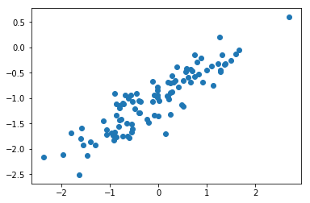

```python
#part(d)
import matplotlib.pyplot as plt

plt.scatter(X1,Y1)
```

X and Y are nearly positively relative.

```python
#part(e)
X2= sm.add_constant(X)

model8 = sm.OLS(Y1,X2).fit()

print(model8.params)
```

```
[-1.04409137  0.01356952]
```

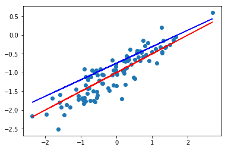

```python
#part(f)
plt.scatter(X1,Y1)
plt.plot(X1,-1 + 0.5*X1,'r')
plt.plot(X1, -0.75049222 + 0.44058306*X1, 'b' )

plt.show()
```

```python
#part(g)
import statsmodels.formula.api as smf

data = {"Y1": Y1, "X1": X1}

model9 = smf.ols(formula = 'Y1 ~ np.power(X1,2) + X1', data = data).fit()

print(model9.params)

table = sm.stats.anova_lm(model9,type = 2)

print(table)
```

```
Intercept         -0.996210
np.power(X1, 2)    0.005290
X1                 0.564663
dtype: float64
                   df     sum_sq    mean_sq           F        PR(>F)
np.power(X1, 2)   1.0   0.009219   0.009219    0.134242  7.148715e-01
X1                1.0  27.351537  27.351537  398.277387  4.092429e-36
Residual         97.0   6.661435   0.068675         NaN           NaN
```

```
[-1.05679919  0.00845146]
```

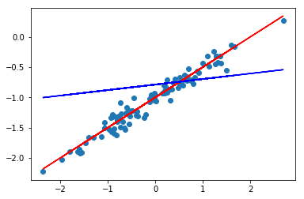

```python
#part(h)

np.random.seed(11111)

eps2 = np.random.normal(0,0.1,100)

Y2 = -1 + 0.5*X1 + eps2

model10 = sm.OLS(Y2,X2).fit()

print(model10.params)

plt.scatter(X1,Y2)
plt.plot(X1,-1 + 0.5*X1,'r')
plt.plot(X1, -0.7887987 + 0.09120311*X1, 'b' )
plt.show()
```

```
[-1.15037271  0.02118244]
```

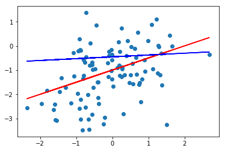

```python
# part(i)
np.random.seed(11111)

eps3 = np.random.normal(0,1,100)

Y3 = -1 + 0.5*X1 + eps3

model11 = sm.OLS(Y3,X2).fit()

print(model11.params)

plt.scatter(X1,Y3)
plt.plot(X1,-1 + 0.5*X1,'r')
plt.plot(X1, -0.45189999 + 0.07522537*X1, 'b' )
plt.show()
```

#### part(j)

```python
model8.summary()
```

OLS Regression Results

| Dep. Variable: | y | R-squared: | 0.000 |
| --- | --- | --- | --- |
| Model: | OLS | Adj. R-squared: | -0.010 |
| Method: | Least Squares | F-statistic: | 0.04620 |
| Date: | Thu, 31 Jan 2019 | Prob (F-statistic): | 0.830 |
| Time: | 14:16:25 | Log-Likelihood: | -87.962 |
| No. Observations: | 100 | AIC: | 179.9 |
| Df Residuals: | 98 | BIC: | 185.1 |
| Df Model: | 1 |  |  |
| Covariance Type: | nonrobust |  |  |

|  | coef | std err | t | P>\|t\| | [0.025 | 0.975] |
| --- | --- | --- | --- | --- | --- | --- |
| const | -1.0441 | 0.059 | -17.723 | 0.000 | -1.161 | -0.927 |
| x1 | 0.0136 | 0.063 | 0.215 | 0.830 | -0.112 | 0.139 |

| Omnibus: | 0.419 | Durbin-Watson: | 1.794 |
| --- | --- | --- | --- |
| Prob(Omnibus): | 0.811 | Jarque-Bera (JB): | 0.572 |
| Skew: | 0.027 | Prob(JB): | 0.751 |
| Kurtosis: | 2.633 | Cond. No. | 1.07 |

Warnings:  
[1] Standard Errors assume that the covariance matrix of the errors is correctly specified.

```python
model10.summary()
```

OLS Regression Results

| Dep. Variable: | y | R-squared: | 0.000 |
| --- | --- | --- | --- |
| Model: | OLS | Adj. R-squared: | -0.010 |
| Method: | Least Squares | F-statistic: | 0.02733 |
| Date: | Thu, 31 Jan 2019 | Prob (F-statistic): | 0.869 |
| Time: | 14:16:25 | Log-Likelihood: | -66.854 |
| No. Observations: | 100 | AIC: | 137.7 |
| Df Residuals: | 98 | BIC: | 142.9 |
| Df Model: | 1 |  |  |
| Covariance Type: | nonrobust |  |  |

|  | coef | std err | t | P>\|t\| | [0.025 | 0.975] |
| --- | --- | --- | --- | --- | --- | --- |
| const | -1.0568 | 0.048 | -22.155 | 0.000 | -1.151 | -0.962 |
| x1 | 0.0085 | 0.051 | 0.165 | 0.869 | -0.093 | 0.110 |

| Omnibus: | 0.074 | Durbin-Watson: | 1.959 |
| --- | --- | --- | --- |
| Prob(Omnibus): | 0.964 | Jarque-Bera (JB): | 0.235 |
| Skew: | 0.029 | Prob(JB): | 0.889 |
| Kurtosis: | 2.770 | Cond. No. | 1.07 |

Warnings:  
[1] Standard Errors assume that the covariance matrix of the errors is correctly specified.

```python
model11.summary()
```

OLS Regression Results

| Dep. Variable: | y | R-squared: | 0.000 |
| --- | --- | --- | --- |
| Model: | OLS | Adj. R-squared: | -0.010 |
| Method: | Least Squares | F-statistic: | 0.03133 |
| Date: | Thu, 31 Jan 2019 | Prob (F-statistic): | 0.860 |
| Time: | 14:16:25 | Log-Likelihood: | -151.91 |
| No. Observations: | 100 | AIC: | 307.8 |
| Df Residuals: | 98 | BIC: | 313.0 |
| Df Model: | 1 |  |  |
| Covariance Type: | nonrobust |  |  |

|  | coef | std err | t | P>\|t\| | [0.025 | 0.975] |
| --- | --- | --- | --- | --- | --- | --- |
| const | -1.1504 | 0.112 | -10.301 | 0.000 | -1.372 | -0.929 |
| x1 | 0.0212 | 0.120 | 0.177 | 0.860 | -0.216 | 0.259 |

| Omnibus: | 2.211 | Durbin-Watson: | 1.959 |
| --- | --- | --- | --- |
| Prob(Omnibus): | 0.331 | Jarque-Bera (JB): | 1.785 |
| Skew: | -0.176 | Prob(JB): | 0.410 |
| Kurtosis: | 2.448 | Cond. No. | 1.07 |

Warnings:  
[1] Standard Errors assume that the covariance matrix of the errors is correctly specified.

```python
from matplotlib import pyplot as plt
from pandas.tools.plotting import scatter_matrix
from mpl_toolkits.mplot3d import Axes3D
from statsmodels.stats.outliers_influence import OLSInfluence

%matplotlib inline
plt.style.use('ggplot')
```

## Exercise 3.14

```python
#part(a)

np.random.seed(2)

a1 = np.random.random(100)

a2 = 0.5*a1 + np.random.randn(100)/10

b =2+2* a1 +0.3* a2 + np.random.randn(100)

data2 = {"b":b , "a1": a1, "a2": a2}
```

```
[[1.         0.81145744]
 [0.81145744 1.        ]]
```

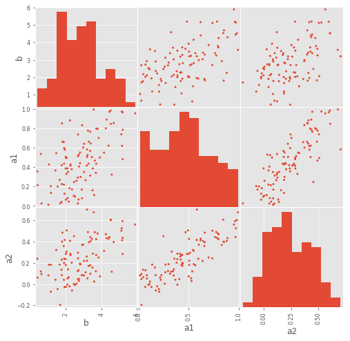

```python
#part(b)
from numpy import corrcoef
print(corrcoef(a1,a2))

df = pd.DataFrame(np.column_stack((b,a1,a2)), columns=['b','a1','a2'] )
df.head()


scatter_matrix(df, figsize = (8,8),alpha=1);
```

```python
#part(c)
model12 = smf.ols(formula = 'b ~ a1 + a2', data = data2).fit()

print(model12.summary())

print(model12.params)
```

```
                            OLS Regression Results
==============================================================================
Dep. Variable:                      b   R-squared:                       0.335
Model:                            OLS   Adj. R-squared:                  0.322
Method:                 Least Squares   F-statistic:                     24.47
Date:                Thu, 31 Jan 2019   Prob (F-statistic):           2.48e-09
Time:                        14:16:26   Log-Likelihood:                -137.23
No. Observations:                 100   AIC:                             280.5
Df Residuals:                      97   BIC:                             288.3
Df Model:                           2
Covariance Type:            nonrobust
==============================================================================
                 coef    std err          t      P>|t|      [0.025      0.975]
------------------------------------------------------------------------------
Intercept      1.7199      0.195      8.817      0.000       1.333       2.107
a1             1.8561      0.624      2.975      0.004       0.618       3.095
a2             1.1244      0.874      1.287      0.201      -0.610       2.859
==============================================================================
Omnibus:                        0.358   Durbin-Watson:                   1.843
Prob(Omnibus):                  0.836   Jarque-Bera (JB):                0.501
Skew:                          -0.120   Prob(JB):                        0.778
Kurtosis:                       2.749   Cond. No.                         12.1
==============================================================================

Warnings:
[1] Standard Errors assume that the covariance matrix of the errors is correctly specified.
Intercept    1.719888
a1           1.856144
a2           1.124409
dtype: float64
```

```python
# part(c)-(e)
model13 = smf.ols(formula = 'b ~ a1', data = data2).fit()

print(model13.summary())

model14 = smf.ols(formula = 'b ~ a2', data = data2).fit()

print(model14.summary())
```

```
                            OLS Regression Results
==============================================================================
Dep. Variable:                      b   R-squared:                       0.324
Model:                            OLS   Adj. R-squared:                  0.317
Method:                 Least Squares   F-statistic:                     46.98
Date:                Thu, 31 Jan 2019   Prob (F-statistic):           6.43e-10
Time:                        14:16:26   Log-Likelihood:                -138.08
No. Observations:                 100   AIC:                             280.2
Df Residuals:                      98   BIC:                             285.4
Df Model:                           1
Covariance Type:            nonrobust
==============================================================================
                 coef    std err          t      P>|t|      [0.025      0.975]
------------------------------------------------------------------------------
Intercept      1.6908      0.194      8.698      0.000       1.305       2.077
a1             2.5078      0.366      6.854      0.000       1.782       3.234
==============================================================================
Omnibus:                        0.247   Durbin-Watson:                   1.868
Prob(Omnibus):                  0.884   Jarque-Bera (JB):                0.341
Skew:                          -0.112   Prob(JB):                        0.843
Kurtosis:                       2.823   Cond. No.                         4.61
==============================================================================

Warnings:
[1] Standard Errors assume that the covariance matrix of the errors is correctly specified.
                            OLS Regression Results
==============================================================================
Dep. Variable:                      b   R-squared:                       0.275
Model:                            OLS   Adj. R-squared:                  0.267
Method:                 Least Squares   F-statistic:                     37.12
Date:                Thu, 31 Jan 2019   Prob (F-statistic):           2.18e-08
Time:                        14:16:26   Log-Likelihood:                -141.60
No. Observations:                 100   AIC:                             287.2
Df Residuals:                      98   BIC:                             292.4
Df Model:                           1
Covariance Type:            nonrobust
==============================================================================
                 coef    std err          t      P>|t|      [0.025      0.975]
------------------------------------------------------------------------------
Intercept      2.0661      0.163     12.702      0.000       1.743       2.389
a2             3.2334      0.531      6.093      0.000       2.180       4.286
==============================================================================
Omnibus:                        1.173   Durbin-Watson:                   1.787
Prob(Omnibus):                  0.556   Jarque-Bera (JB):                1.095
Skew:                          -0.093   Prob(JB):                        0.578
Kurtosis:                       2.522   Cond. No.                         5.58
==============================================================================

Warnings:
[1] Standard Errors assume that the covariance matrix of the errors is correctly specified.
```

#### part(f)

In model13, $b \sim a_1$, we find that the coeffecient is close to the true value and is now very significant. In model14 $b \sim a_2$, we find that the coeffecient for $a_2$ is now very significant. Note there is no contradiction here. $a_1$ and $a_2$ are strongly correlated and each is related to $b$ independent of each other.

[output not shown]

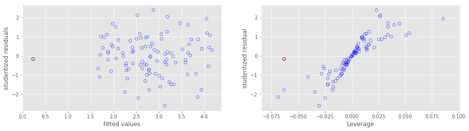

```python
df.loc[len(df)] = [0.1, 0.8, 6]

A = sm.add_constant(df[['a1','a2']])
model = sm.OLS(df.b, A)
estimate = model.fit()

print(estimate.summary())

# Obtain the residuals, studentized residuals and the leverages
fitted_values = estimate.fittedvalues.values
residuals = estimate.resid.values
studentized_residuals = OLSInfluence(estimate).resid_studentized_internal
leverages = OLSInfluence(estimate).influence

# Plot
fig, (ax1,ax2) = plt.subplots(1,2,figsize=(16,4))

# Studentized Residuals
ax1.scatter(fitted_values[:-1], studentized_residuals[:-1], facecolors='none', edgecolors='b');
# Plot the possible Outlier in red
ax1.scatter(fitted_values[-1], studentized_residuals[-1], facecolors='none', edgecolors='r');
ax1.set_xlabel('fitted values');
ax1.set_ylabel('studentized residuals');

# Leverages
ax2.scatter(leverages[:-1], studentized_residuals[:-1], facecolors='none', edgecolors='b');
# plot the possible high leverager in red
ax2.scatter(leverages[-1], studentized_residuals[-1], facecolors='none', edgecolors='r');
ax2.set_xlabel('Leverage');
ax2.set_ylabel('studentized residual');
```